# Networks Project

Logan Eades

2026-06-26

```r
#reading in the libraries we will need for the project
library(igraph)
library(ggraph)
library(gplots)
library(dplyr)
library(sna)
library(ggpubr)
library(intergraph)
library(lme4)
library(lmerTest)
library(magrittr)
library(netdiffuseR)
```

```r
#reading in the edges and nodes data
edges <- read.table("./Airport Edge Data 2010.txt")
nodes <- read.table("./Airport 2010 Nodes.txt")

#renaming the edges
edges <- edges %>%
                  rename(Ego = V1,
                         Alter = V2,
                         Strength = V3)

#renaming the nodes
nodes <- nodes %>% rename(ID = V1,
                          Airport = V2)

#okay so this was a weird part of the project.
#Basically, a bunch of the nodes were isolates and made the graph look really clunky
#so, I made a list of all unqiue edges and alters in the edge list
edges_list <- append(unique(edges$Ego), unique(edges$Alter))

#and then made a subset of the nodes list where I kept the ID and the airport
nodes <- subset(nodes, ID %in% edges_list, select = c(ID, Airport))

#we also then noticed that the data had two nodes that only connected with each other and nothing else which broke some of our models
#Airport LCI and NY5
nodes <- nodes[nodes$Airport != 'LCI', ]
nodes <- nodes[nodes$Airport != 'NY5', ]

edges <- edges[edges$Ego != '889' & edges$Alter != '889' ,]

#and could finally make a net diagram with minimal isolates
net <- graph_from_data_frame(edges, directed = T, vertices = nodes)
```

#3. Visualizations

```r
#basic plot of the igraph
airport_plot <- ggraph(net) +
  geom_edge_link(color = "black", alpha = 0.3) +
  geom_node_point(color = "black", fill = "#efd9d3", shape = 21) +
  theme_graph()
```

```
## Using "stress" as default layout
```

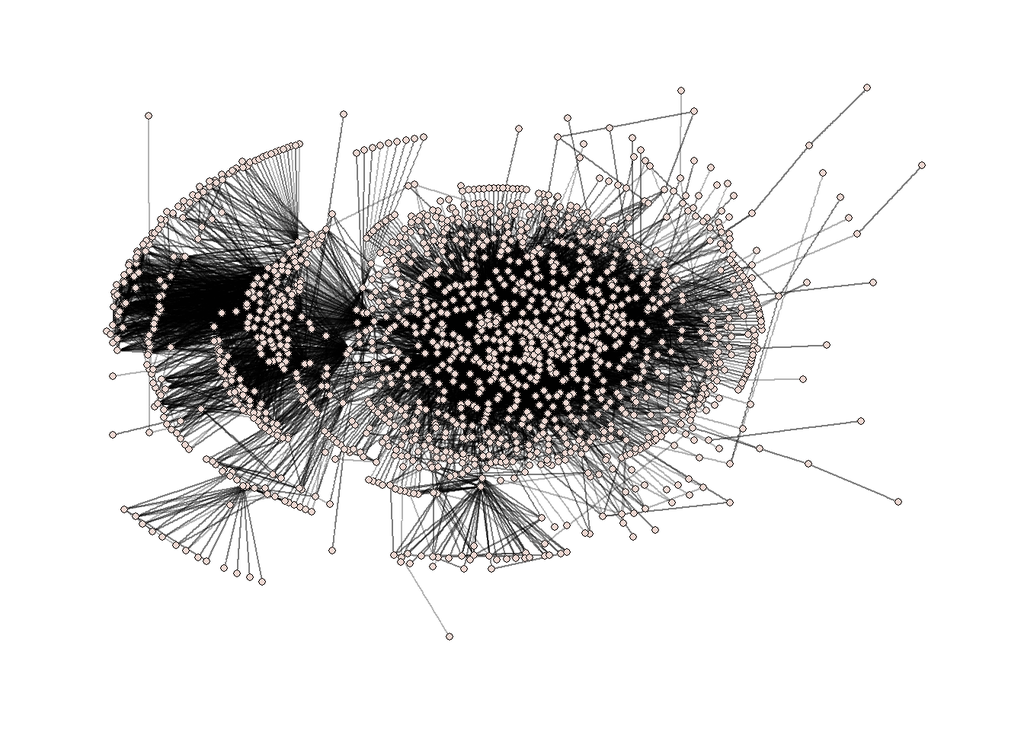

```r
#Saving the plot to PNG
## png("airport_network.png", width = 5000, height = 4000, res = 300)
print(airport_plot)
```

```r
## dev.off()
```

#4. Centrality

```r
#getting the degrees and making it into a df
deg <- igraph::degree(net)
airport_degs <- as.data.frame(deg)

#making a scaled plot with limited labels
airport_plot_scaled <- ggraph(net) +
                        geom_edge_link0(color = "black", alpha = .5) +
                        geom_node_point(fill = "#EFD9D3", color = "black", shape = 21,
                        size = V(net)$deg <- igraph::degree(net, mode = "all") / 50) +
                        geom_node_label(aes(filter = deg > 4.5, label = Airport),
                                            max.overlaps = Inf, label.size = 0.1) +
                        theme_graph()
```

```
## Using "stress" as default layout
```

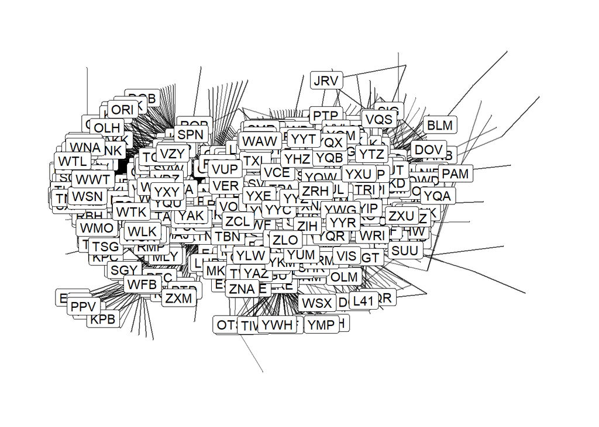

```r
#we wrote it out in high detail so we could have a good plot for the presentation
## png("airport_network_scaled.png", width = 10000, height = 10000, res = 300)
print(airport_plot_scaled)
```

```r
## dev.off()


#getting the out mapping and making a df
deg_out <- igraph::degree(net, mode = "out")
airpot_out_data <- as.data.frame(deg_out)

#plotting it
airport_out <- ggraph(net) +
                geom_edge_link(color = "black", alpha = .5, arrow = grid::arrow(angle = 20,
                                length = unit(0.10, "in"), type = "closed"),
                                start_cap = circle(2, 'mm'), end_cap = circle(2, 'mm')) +
                                geom_node_point(fill = "#EFD9D3", color = "black", shape = 21,
                                size = igraph::degree(net, mode = "out") / 20) +
                                ggnetwork::theme_blank()
```

```
## Using "stress" as default layout
```

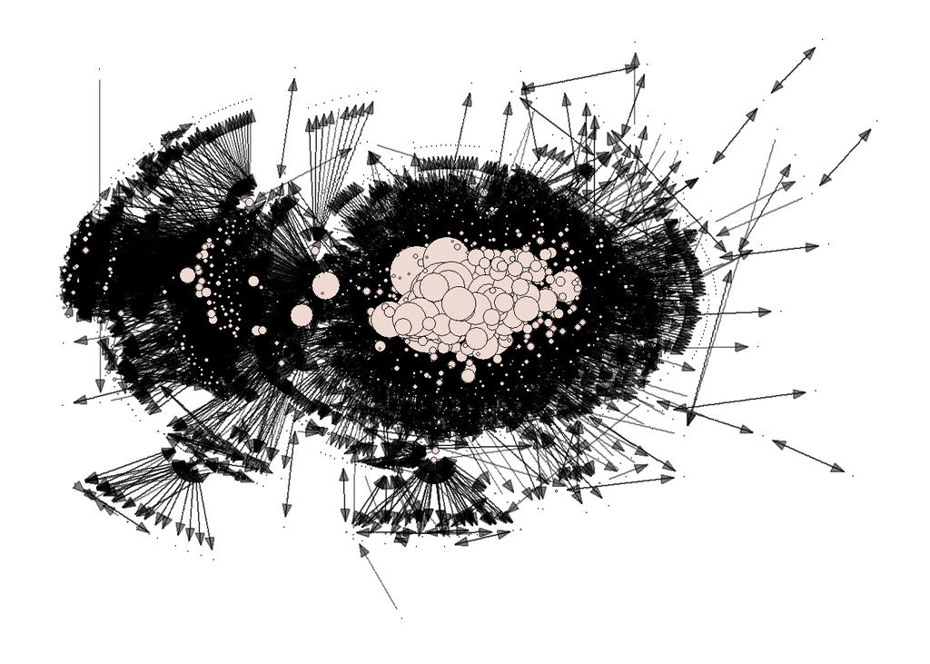

```r
#writing it out
## png("airport_out.png", width = 5000, height = 4000, res = 300)
print(airport_out)
```

```r
## dev.off()

#getting the in degree and writing it out
deg_in <- igraph::degree(net, mode = "in") #in degree

#plotting
airport_in <-  ggraph(net) +
                geom_edge_link(color = "black", alpha = .5, arrow = grid::arrow(angle = 20,
                                length = unit(0.10, "in"), type = "closed"),
                                start_cap = circle(2, 'mm'), end_cap = circle(2, 'mm')) +
                                geom_node_point(fill = "#EFD9D3", color = "black", shape = 21,
                                size = igraph::degree(net, mode = "in") / 20) +
                                ggnetwork::theme_blank()
```

```
## Using "stress" as default layout
```

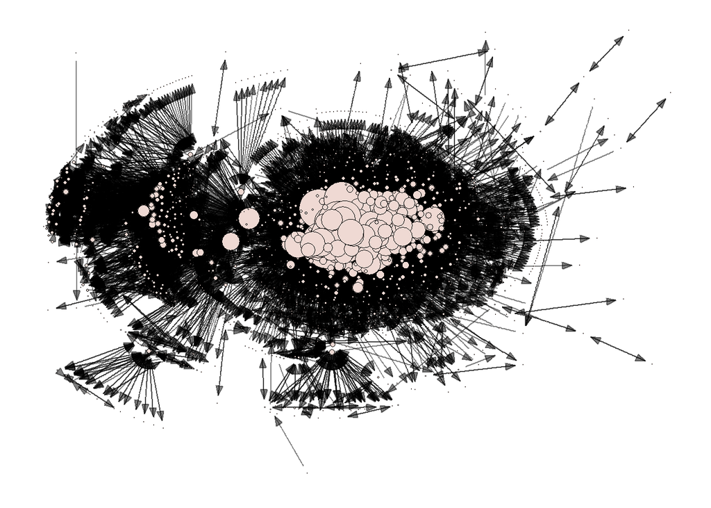

```r
#writing it out
## png("airport_in.png", width = 5000, height = 4000, res = 300)
print(airport_in)
```

```r
## dev.off()

#getting the eigenvector centrality
evc_undir <- eigen_centrality(net, directed = F)$vector

#plotting it
eig_airport <- ggraph(net) +
                geom_edge_link(color = "black", alpha = .5) +
                geom_node_point(fill = "#EFD9D3", color = "black", shape = 21,
                size = igraph::eigen_centrality(net)$vector*10) +
                geom_node_label(aes(filter = deg > 4.5, label = Airport),
                                max.overlaps = Inf, label.size = 0.1) +
                ggnetwork::theme_blank()
```

```
## Using "stress" as default layout
```

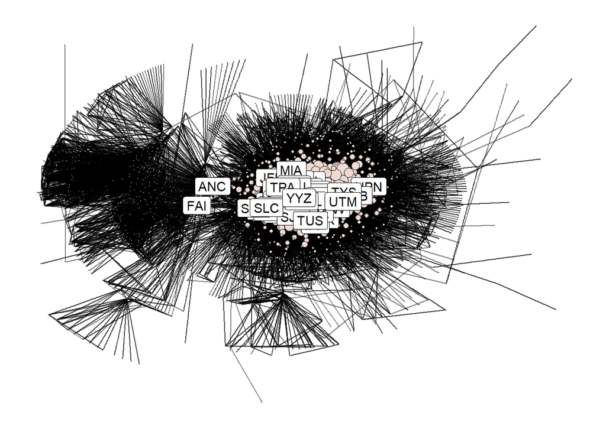

```r
#writing it out to the desktop
## png("eig_airport.png", width = 5000, height = 4000, res = 300)
print(eig_airport)
```

```r
## dev.off()
```

#5. Structuring

```r
igraph::dyad_census(net)
```

```
## $mut
## [1] 11021
##
## $asym
## [1] 6193
##
## $null
## [1] 1217592
```

```r
igraph::reciprocity(net)
```

```
## [1] 0.7806623
```

```r
igraph::triad_census(net)
```

```
##  [1] 620858679   8765143  15166971     40817     31451     69929    215419
##  [8]    277823      5480      1788    543736      7739     11121     17919
## [15]     84869    116256
```

```r
trans <- igraph::transitivity(net, type = "average")
trans
```

```
## [1] 0.2244343
```

```r
net_sna_adj <- as.matrix(as_adjacency_matrix(net))
triad_df <- as.data.frame(sna::triad.census(net_sna_adj))

average_local_efficiency(net)
```

```
## [1] 0.6142249
```

```r
igraph::diameter(net, directed = F)
```

```
## [1] 8
```

```r
#### density####
den <- igraph::edge_density(net)
den
```

```
## [1] 0.01143297
```

```r
# efficiency####
global_efficiency(net)
```

```
## [1] 0.3068573
```

```r
# Global efficiency is the average of the inverse distances between all pairs of nodes
# 0 if pair isn't reachable

average_local_efficiency(net)
```

```
## [1] 0.6142249
```

```r
# Average local efficiency is the mean of the local efficiencies

igraph::farthest_vertices(net, directed = F)
```

```
## $vertices
## + 2/1572 vertices, named, from 0274f32:
## [1] 277  1740
##
## $distance
## [1] 8
```

```r
igraph::get_diameter(net, directed = F)
```

```
## + 9/1572 vertices, named, from 0274f32:
## [1] 277  1721 71   88   215  1221 198  172  1740
```

Overall, the network largely consisted of roughly 620 million 003 triads, which makes sense because not every airport is going to have a tie with one-another. Next was 102, which said that some airports did have mutual ties (which makes sense) but weren’t connect to the third airport in the triad. The best way to think of this is how Miami has a mutual flight to Atlanta, but neither would have a flight to a small regional airport in Washington State. Generally, hubs go to hubs.

The diameter of the network was 8, meaning it would take 8 ‘flights’ to cross the network at its longest point.

The density of the network was 1%, which is very, very sparse, but it also makes sense because the vast majority of the small regional airports generally had a limited number of connections.

The network did have a strong local efficiency, which means that people could get to their destination if a connecting airport were to go down because of weather.

The global efficiency was lower than the local efficiency, so information (or in our case, delays) will move through the network at a reasonable rate, though in some cases it will take time.

#6. Clustering/Communities

```r
#Look at the object and make sure it is simple. If not we convert it
net
```

```
## IGRAPH 0274f32 DN-- 1572 28235 --
## + attr: name (v/c), Airport (v/c), deg (v/n), Strength (e/n)
## + edges from 0274f32 (vertex names):
##  [1] 1 ->47   1 ->832  2 ->679  3 ->424  3 ->1688 4 ->685  6 ->47   7 ->679
##  [9] 8 ->1217 8 ->1729 9 ->91   11->679  11->1494 12->227  12->505  12->509
## [17] 13->505  15->47   16->844  17->227  19->679  20->70   20->88   20->464
## [25] 20->1131 20->1262 20->1652 20->1739 21->679  22->679  23->679  24->679
## [33] 27->505  27->1416 29->78   29->114  29->117  29->134  29->169  29->173
## [41] 29->206  29->296  29->300  29->311  29->317  29->381  29->391  29->403
## [49] 29->432  29->435  29->489  29->526  29->534  29->576  29->609  29->610
## [57] 29->619  29->691  29->709  29->716  29->727  29->731  29->760  29->766
## + ... omitted several edges
```

```r
is.simple(net)
```

```
## [1] TRUE
```

```r
net_s <- igraph::simplify(net)
is.simple(net_s)
```

```
## [1] TRUE
```

```r
net_s_sna <- asNetwork(net_s) #converts igraph to sna object

net_sna <- network(edges, matrix.type = "edgelist", directed = T)
net_sna
```

```
##  Network attributes:
##   vertices = 1572
##   directed = TRUE
##   hyper = FALSE
##   loops = FALSE
##   multiple = FALSE
##   bipartite = FALSE
##   total edges= 28235
##     missing edges= 0
##     non-missing edges= 28235
##
##  Vertex attribute names:
##     vertex.names
##
##  Edge attribute names not shown
```

```r
un_net <- graph_from_data_frame(edges, directed = F, vertices = nodes)
un_net
```

```
## IGRAPH 0ee04ac UN-- 1572 28235 --
## + attr: name (v/c), Airport (v/c), Strength (e/n)
## + edges from 0ee04ac (vertex names):
##  [1] 1 --47   1 --832  2 --679  3 --424  3 --1688 4 --685  6 --47   7 --679
##  [9] 8 --1217 8 --1729 9 --91   11--679  11--1494 12--227  12--505  12--509
## [17] 13--505  15--47   16--844  17--227  19--679  20--70   20--88   20--464
## [25] 20--1131 20--1262 20--1652 20--1739 21--679  22--679  23--679  24--679
## [33] 27--505  27--1416 29--78   29--114  29--117  29--134  29--169  29--173
## [41] 29--206  29--296  29--300  29--311  29--317  29--381  29--391  29--403
## [49] 29--432  29--435  29--489  29--526  29--534  29--576  29--609  29--610
## [57] 29--619  29--691  29--709  29--716  29--727  29--731  29--760  29--766
## + ... omitted several edges
```

```r
s_un_net <- simplify(un_net)
s_un_net
```

```
## IGRAPH 0ee232a UN-- 1572 17214 --
## + attr: name (v/c), Airport (v/c)
## + edges from 0ee232a (vertex names):
##  [1] 1 --47   1 --832  2 --679  3 --424  3 --1688 4 --685  6 --47   6 --81
##  [9] 7 --679  8 --1217 8 --1729 9 --91   10--91   10--1672 11--88   11--679
## [17] 11--1494 12--227  12--236  12--505  12--509  13--505  14--47   15--47
## [25] 16--830  16--844  17--227  19--679  20--70   20--88   20--464  20--1131
## [33] 20--1262 20--1652 20--1739 21--679  22--679  23--679  24--679  27--505
## [41] 27--1416 29--41   29--78   29--114  29--117  29--126  29--134  29--164
## [49] 29--169  29--173  29--204  29--206  29--237  29--256  29--296  29--300
## [57] 29--311  29--317  29--321  29--322  29--381  29--383  29--389  29--391
## + ... omitted several edges
```

```r
is_simple(s_un_net)
```

```
## [1] TRUE
```

```
## Using "stress" as default layout
```

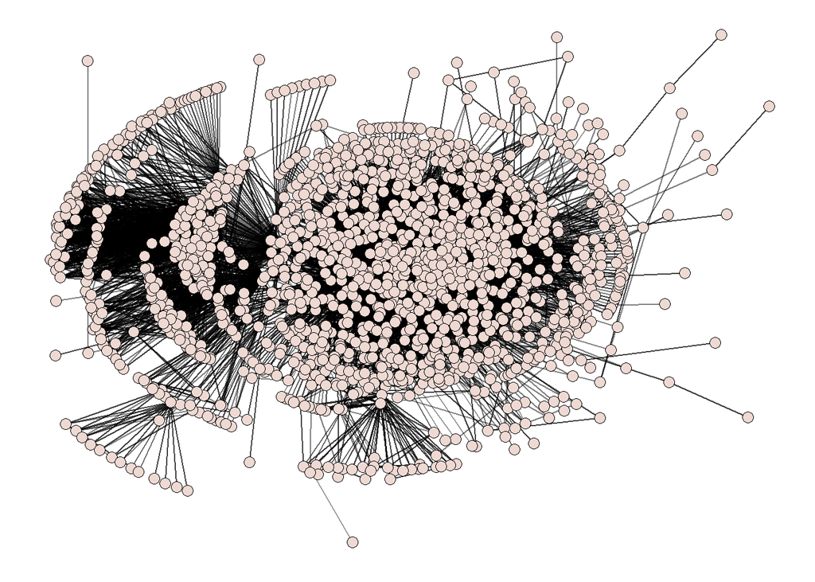

```r
## plot of net
ggraph(net) +
  geom_edge_link0(color = "black", alpha = .5) +
  geom_node_point(fill = "#EFD9D3", color = "black",
                  size = 3, shape = 21) +
  ggnetwork::theme_blank()
```

```
## Using "stress" as default layout
```

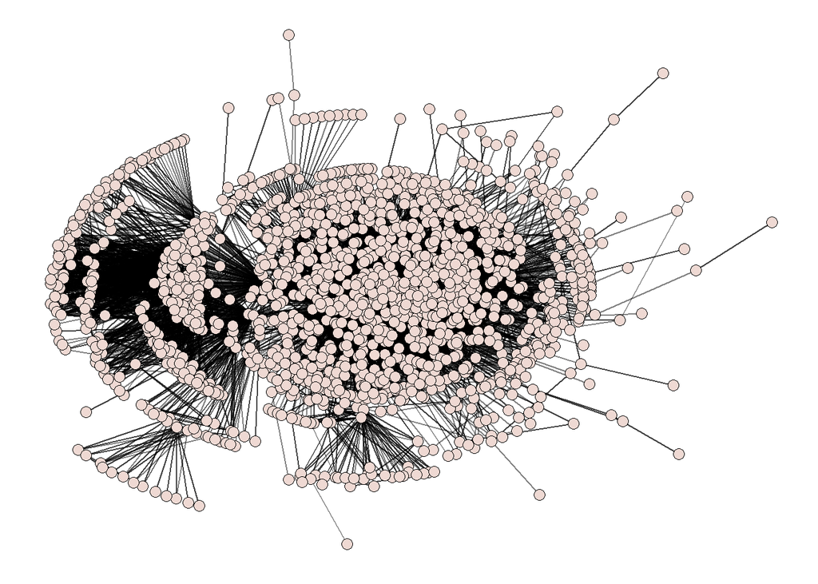

```r
## plot of net_sna
ggraph(net_sna) +
  geom_edge_link0(color = "black", alpha = .5) +
  geom_node_point(fill = "#EFD9D3", color = "black",
                  size = 3, shape = 21) +
  ggnetwork::theme_blank()
```

```r
## Spinglass####
#^This function has a gamma parameter that we can tweak!!
set.seed(1)
csg <- cluster_spinglass(net)
modularity(csg)
```

```
## [1] 0.2809825
```

```r
#commented out for sake of knitting readability
#membership(csg)
length(csg)
```

```
## [1] 12
```

```r
sizes(csg)
```

```
## Community sizes
##   1   2   3   4   5   6   7   8   9  10  11  12
##   2  56 297 447  18  58   4  46   1  89 248 306
```

```
## Using "stress" as default layout
```

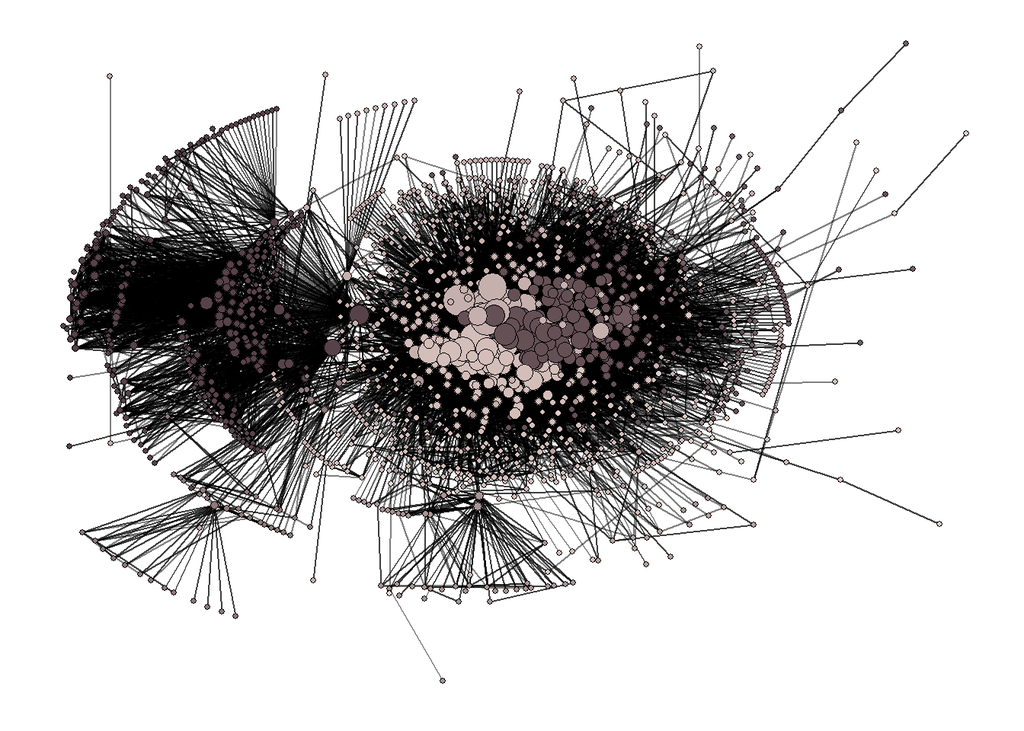

```r
# plot####
colors <- colorpanel(length(csg), low = "#efd9d3", high = "#57424a")
ggraph(net) +
  geom_edge_link0(color = "black", alpha = .5) +
  geom_node_point(aes(fill = as.factor(membership(csg))),
                  size = scales::rescale(igraph::degree(net, mode = "all"), to = c(1, 8)),
                  color = "black", shape = 21) +
  scale_fill_manual(values = c(colors)) +
  ggnetwork::theme_blank() +
  theme(legend.position = "none")
```

```r
# tuning parameters####
set.seed(1)
csg_1 <- cluster_spinglass(net, gamma = 0.25)
length(csg_1)
```

```
## [1] 11
```

```r
csg_2 <- cluster_spinglass(net, gamma = 0.5)
length(csg_2)
```

```
## [1] 14
```

```r
csg_3 <- cluster_spinglass(net, gamma = 0.75)
length(csg_3)
```

```
## [1] 20
```

```r
csg_4 <- cluster_spinglass(net, gamma = 1)
length(csg_4)
```

```
## [1] 12
```

```r
csg_5 <- cluster_spinglass(net, gamma = 2)
length(csg_5)
```

```
## [1] 25
```

```r
csg_6 <- cluster_spinglass(net, gamma = 3)
length(csg_6)
```

```
## [1] 25
```

```r
modularity(csg_1)
```

```
## [1] 0.5320851
```

```r
modularity(csg_2)
```

```
## [1] 0.4564991
```

```r
modularity(csg_3)
```

```
## [1] 0.3793382
```

```r
modularity(csg_4)
```

```
## [1] 0.2822124
```

```r
modularity(csg_5)
```

```
## [1] 0.1568959
```

```r
modularity(csg_6)
```

```
## [1] 0.1288072
```

```r
colors <- colorpanel(length(csg_1), low = "#efd9d3", high = "#57424a")
csg_1_plot <- ggraph(net) +
  geom_edge_link0(color = "black", alpha = .5) +
  geom_node_point(aes(fill = as.factor(membership(csg_1))),
                  size = scales::rescale(igraph::degree(net, mode = "all"), to = c(1, 8)),
                  color = "black", shape = 21) +
  scale_fill_manual(values = c(colors)) +
  ggnetwork::theme_blank() +
  geom_node_text(aes(label = as.factor(membership(csg_1))), repel = T) +
  theme(legend.position = "none")
```

```
## Using "stress" as default layout
```

```r
colors <- colorpanel(length(csg_2), low = "#efd9d3", high = "#57424a")
csg_2_plot <- ggraph(net) +
  geom_edge_link0(color = "black", alpha = .5) +
  geom_node_point(aes(fill = as.factor(membership(csg_2))),
                  size = scales::rescale(igraph::degree(net, mode = "all"), to = c(1, 8)),
                  color = "black", shape = 21) +
  scale_fill_manual(values = c(colors)) +
  ggnetwork::theme_blank() +
  geom_node_text(aes(label = as.factor(membership(csg_2))), repel = T) +
  theme(legend.position = "none")
```

```
## Using "stress" as default layout
```

```r
colors <- colorpanel(length(csg_3), low = "#efd9d3", high = "#57424a")
csg_3_plot <- ggraph(net) +
  geom_edge_link0(color = "black", alpha = .5) +
  geom_node_point(aes(fill = as.factor(membership(csg_3))),
                  size = scales::rescale(igraph::degree(net, mode = "all"), to = c(1, 8)),
                  color = "black", shape = 21) +
  scale_fill_manual(values = c(colors)) +
  ggnetwork::theme_blank() +
  geom_node_text(aes(label = as.factor(membership(csg_3))), repel = T) +
  theme(legend.position = "none")
```

```
## Using "stress" as default layout
```

```r
colors <- colorpanel(length(csg_4), low = "#efd9d3", high = "#57424a")
csg_4_plot <- ggraph(net) +
  geom_edge_link0(color = "black", alpha = .5) +
  geom_node_point(aes(fill = as.factor(membership(csg_4))),
                  size = scales::rescale(igraph::degree(net, mode = "all"), to = c(1, 8)),
                  color = "black", shape = 21) +
  scale_fill_manual(values = c(colors)) +
  ggnetwork::theme_blank() +
  geom_node_text(aes(label = as.factor(membership(csg_4))), repel = T) +
  theme(legend.position = "none")
```

```
## Using "stress" as default layout
```

```r
colors <- colorpanel(length(csg_5), low = "#efd9d3", high = "#57424a")
csg_5_plot <- ggraph(net) +
  geom_edge_link0(color = "black", alpha = .5) +
  geom_node_point(aes(fill = as.factor(membership(csg_5))),
                  size = scales::rescale(igraph::degree(net, mode = "all"), to = c(1, 8)),
                  color = "black", shape = 21) +
  scale_fill_manual(values = c(colors)) +
  ggnetwork::theme_blank() +
  geom_node_text(aes(label = as.factor(membership(csg_5))), repel = T) +
  theme(legend.position = "none")
```

```
## Using "stress" as default layout
```

```r
colors <- colorpanel(length(csg_6), low = "#efd9d3", high = "#57424a")
csg_6_plot <- ggraph(net) +
  geom_edge_link0(color = "black", alpha = .5) +
  geom_node_point(aes(fill = as.factor(membership(csg_6))),
                  size = scales::rescale(igraph::degree(net, mode = "all"), to = c(1, 8)),
                  color = "black", shape = 21) +
  scale_fill_manual(values = c(colors)) +
  ggnetwork::theme_blank() +
  geom_node_text(aes(label = as.factor(membership(csg_6))), repel = T) +
  theme(legend.position = "none")
```

```
## Using "stress" as default layout
```

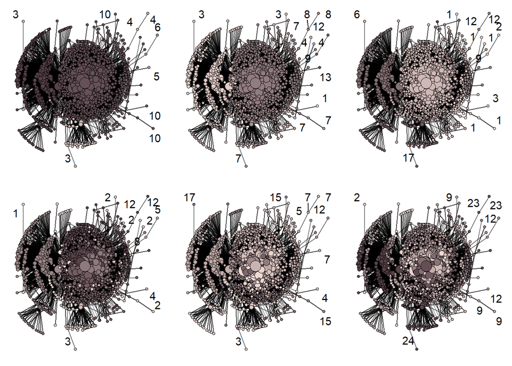

```r
library(ggpubr)
ggarrange(csg_1_plot, csg_2_plot, csg_3_plot, csg_4_plot, csg_5_plot, csg_6_plot,
          nrow = 2, ncol = 3)
```

Louvain

```r
## Louvain method####
# has resolution parameter we can tweak!
set.seed(1)
clv <- cluster_louvain(un_net)
modularity(clv)
```

```
## [1] 0.3580194
```

```r
#commented out for sake of knit readability
#membership(clv)
#commented out for sake of knit readability
#communities(clv)
length(clv)
```

```
## [1] 13
```

```r
sizes(clv)
```

```
## Community sizes
##   1   2   3   4   5   6   7   8   9  10  11  12  13
## 303  18 136 264 317 336   2  46  99   4  42   2   3
```

```
## Using "stress" as default layout
```

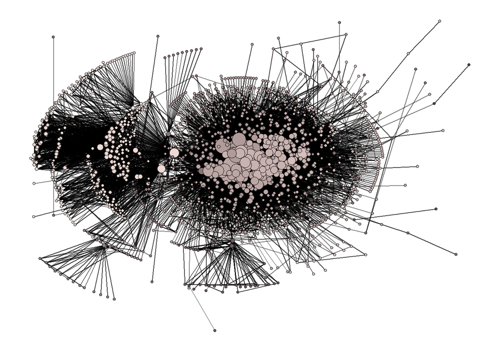

```r
# plot####
colors <- colorpanel(length(clv), low = "#efd9d3", high = "#57424a")
ggraph(net) +
  geom_edge_link0(color = "black", alpha = .5) +
  geom_node_point(aes(fill = as.factor(membership(clv))),
                  size = scales::rescale(igraph::degree(net, mode = "all"), to = c(1, 8)),
                  color = "black", shape = 21) +
  scale_fill_manual(values = c(colors)) +
  ggnetwork::theme_blank() +
  theme(legend.position = "none")
```

Walktrap

```r
## Walktrap####
set.seed(1)
cwt <- cluster_walktrap(net)
modularity(cwt)
```

```
## [1] 0.2581858
```

```r
#commented out for sake of knit readability
#membership(cwt)
length(cwt)
```

```
## [1] 302
```

```
## Using "stress" as default layout
```

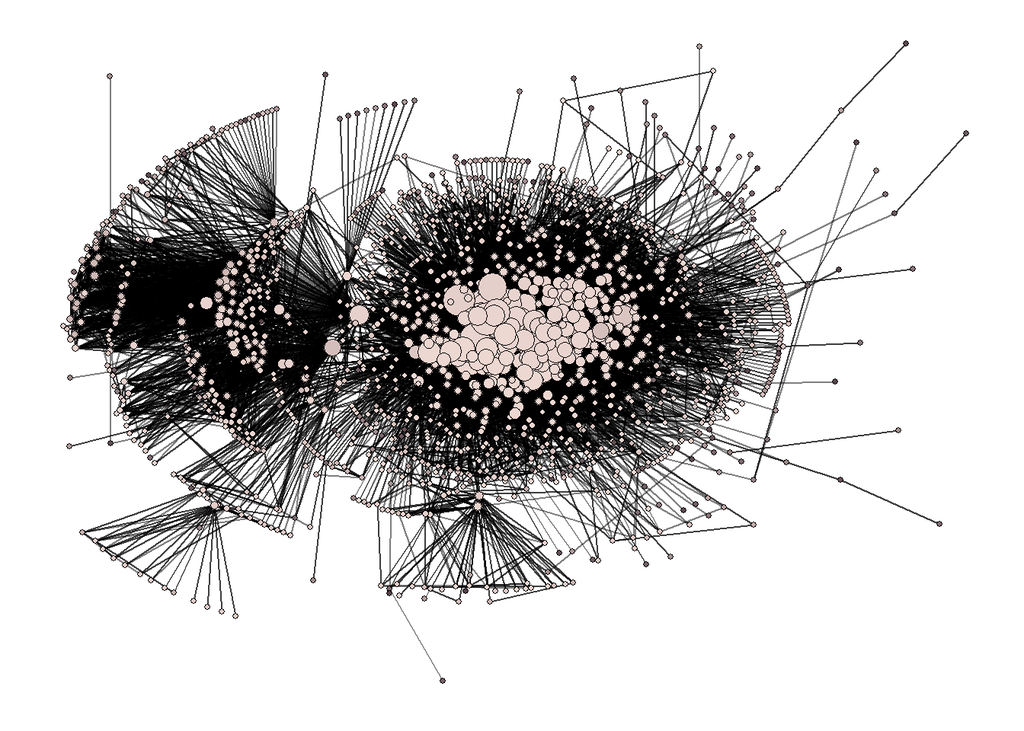

```r
#commented out for sake of knit readability
#sizes(cwt)

# plot####
colors <- colorpanel(length(cwt), low = "#efd9d3", high = "#57424a")
ggraph(net) +
  geom_edge_link0(color = "black", alpha = .5) +
  geom_node_point(aes(fill = as.factor(membership(cwt))),
                  size = scales::rescale(igraph::degree(net, mode = "all"), to = c(1, 8)),
                  color = "black", shape = 21) +
  scale_fill_manual(values = c(colors)) +
  ggnetwork::theme_blank() +
  theme(legend.position = "none")
```

Cluster 1 Small regional airports in the US/Canada

Cluster 2 Military air bases

Cluster 3 Large regional and mid-size commercial airports in US/Mexico

Cluster 4 International Airports in Europe and Latin America especially

Cluster 5 Very small domestic airports or private fields

Cluster 6 Canadian remote airports and small regional hubs

Cluster 7 Small specialized airports (some niche airports or military-related)

Cluster 8 Seaplane bases, remote Alaskan airfields

Cluster 9 Special testing/military facility

Cluster 10 Small support airports for larger metro areas

Cluster 11 Remote and Cargo Hubs (Alaska, small town US)

Cluster 12 Mix of remote airports and international airports (some in Alaska, Canada, Pacific)

#7. Multi-level Modeling

```r
#renaming the nodes
nodes2 <- nodes %>% rename(Ego = ID)
```

```r
# Merge the edge and node dataframes by "ego" (EX: edges_nodes <- merge(edges, nodes, by = "ego"))
edges_nodes <- merge(edges, nodes2, by = "Ego")
```

Estimate a random intercept model with relationship strength as the DV and Airport as the IV

```r
#1. Random intercept model with co-variates
model1 <- lmer(Strength ~ Airport + (1 | Ego),
               data = edges_nodes, REML = T,
               na.action = na.omit)
#summary(model1)
#we commented out the summary of the model because every single airport had its own intercept
```

Interpret the model results

The model tells us that most of the variability in reported tie strength comes from differences between individual egos rather than from relationship type. The estimated variance of the random intercept for Ego is 1.22 × 10⁹, while the residual (tie‐level) variance is 6.92 × 10⁹, yielding an intraclass correlation of about 0.15. In other words, roughly 15 % of the total variation in relationship strength is due to consistent differences across people, and the remaining 85 % reflects variability among that person’s ties.

On the fixed‐effects side, the intercept of 4.0 represents the mean tie strength for the reference relationship type, and each “AirportXYZ” coefficient represents that type’s deviation from this baseline. However, all of these coefficients carry enormous standard errors and p-values of 1.00, indicating no statistically reliable differences in strength across any of the coded types. Practically speaking, the model has far too many sparse categories in the predictor to estimate meaningful effects.

Taken together, these results show that while individuals differ in their tendency to rate ties as stronger or weaker, the chosen coding of relationship type here does not explain any additional variability. To get interpretable estimates, you would need to collapse categories into a handful of substantively meaningful types (or treat type itself as a random effect), which would reduce noise, improve precision, and allow you to test real differences in tie strength by relationship type.

Calculate the ICC

```r
performance::icc(model1, tolerance = 0) # pretty small
```

```
## # Intraclass Correlation Coefficient
##
##     Adjusted ICC: 0.150
##   Unadjusted ICC: 0.131
```

Interpret the ICC

An unadjusted ICC of 0.131 tells us that, in a model with no predictors, about 13.1 % of the total variance in tie strength lies between egos (with the remaining 86.9 % occurring within an ego’s ties). Once you include relationship type as a fixed effect, the adjusted ICC rises slightly to 0.150, meaning that after accounting for any systematic mean differences due to type, about 15.0 % of the residual variance still resides at the ego level. In practical terms, these figures confirm that people differ moderately in their overall tendency to report strong or weak ties—roughly one‐seventh of the variability in strength ratings is attributable to individual‐level consistency, while the bulk of variation reflects differences among ties within each person.

#9. Contagions

South-Eastern Storm

```r
#making an adjacency matrix
net_sna_adj <- as_adjacency_matrix(net)

#How we found the seeds for each node
#Atlanta
ATL <- match("114", rownames(net_sna_adj))
#Orlando
MCO <- match("982", rownames(net_sna_adj))
#Miami
MIA <- match("1016", rownames(net_sna_adj))
#Tampa
TPA <- match("1613", rownames(net_sna_adj))

#seed for repeatability
set.seed(1)

#running the infection
diffnet_il_se <- rdiffnet(
  #time = 24 for 24 hours
  t = 24,
  seed.graph = net_sna_adj,
  seed.nodes = c(ATL, MCO, MIA, TPA), # Atlanta, Orlando, TB, Miami
  rewire = F,
  threshold.dist = function(i) 0.17, #severe storms
  exposure.args = list(normalized = T))

diffnet_il_se
```

```
## Dynamic network of class -diffnet-
##  Name               : A diffusion network
##  Behavior           : Random contagion
##  # of nodes         : 1572 (1, 2, 3, 4, 6, 7, 8, 9, ...)
##  # of time periods  : 24 (1 - 24)
##  Type               : directed
##  Final prevalence   : 0.94
##  Static attributes  : real_threshold (1)
##  Dynamic attributes : -
```

```r
#getting a summary
summary(diffnet_il_se)
```

```
## Diffusion network summary statistics
## Name     : A diffusion network
## Behavior : Random contagion
## -----------------------------------------------------------------------------
##  Period   Adopters   Cum Adopt. (%)   Hazard Rate   Density   Moran's I (sd)
## -------- ---------- ---------------- ------------- --------- ----------------
##        1          4         4 (0.00)             -      0.01 -0.00 (0.00)
##        2        133       137 (0.09)          0.08      0.01  0.02 (0.00) ***
##        3         20       157 (0.10)          0.01      0.01  0.02 (0.00) ***
##        4         98       255 (0.16)          0.07      0.01  0.03 (0.00) ***
##        5         64       319 (0.20)          0.05      0.01  0.03 (0.00) ***
##        6        288       607 (0.39)          0.23      0.01  0.05 (0.00) ***
##        7        356       963 (0.61)          0.37      0.01  0.08 (0.00) ***
##        8        170      1133 (0.72)          0.28      0.01  0.09 (0.00) ***
##        9         44      1177 (0.75)          0.10      0.01  0.08 (0.00) ***
##       10         92      1269 (0.81)          0.23      0.01  0.07 (0.00) ***
##       11         71      1340 (0.85)          0.23      0.01  0.05 (0.00) ***
##       12         91      1431 (0.91)          0.39      0.01  0.03 (0.00) ***
##       13         25      1456 (0.93)          0.18      0.01  0.02 (0.00) ***
##       14         19      1475 (0.94)          0.16      0.01  0.01 (0.00) ***
##       15          1      1476 (0.94)          0.01      0.01  0.01 (0.00) ***
##       16          0      1476 (0.94)          0.00      0.01  0.01 (0.00) ***
##       17          0      1476 (0.94)          0.00      0.01  0.01 (0.00) ***
##       18          0      1476 (0.94)          0.00      0.01  0.01 (0.00) ***
##       19          0      1476 (0.94)          0.00      0.01  0.01 (0.00) ***
##       20          0      1476 (0.94)          0.00      0.01  0.01 (0.00) ***
##       21          0      1476 (0.94)          0.00      0.01  0.01 (0.00) ***
##       22          0      1476 (0.94)          0.00      0.01  0.01 (0.00) ***
##       23          0      1476 (0.94)          0.00      0.01  0.01 (0.00) ***
##       24          0      1476 (0.94)          0.00      0.01  0.01 (0.00) ***
## -----------------------------------------------------------------------------
##  Left censoring  : 0.00 (4)
##  Right centoring : 0.06 (96)
##  # of nodes      : 1572
##
##  Moran's I was computed on contemporaneous autocorrelation using 1/geodesic
##  values. Significane levels  *** <= .01, ** <= .05, * <= .1.
```

```r
#Getting plots
table(diffnet_il_se$toa) # time of adoption
```

```
##
##   1   2   3   4   5   6   7   8   9  10  11  12  13  14  15
##   4 133  20  98  64 288 356 170  44  92  71  91  25  19   1
```

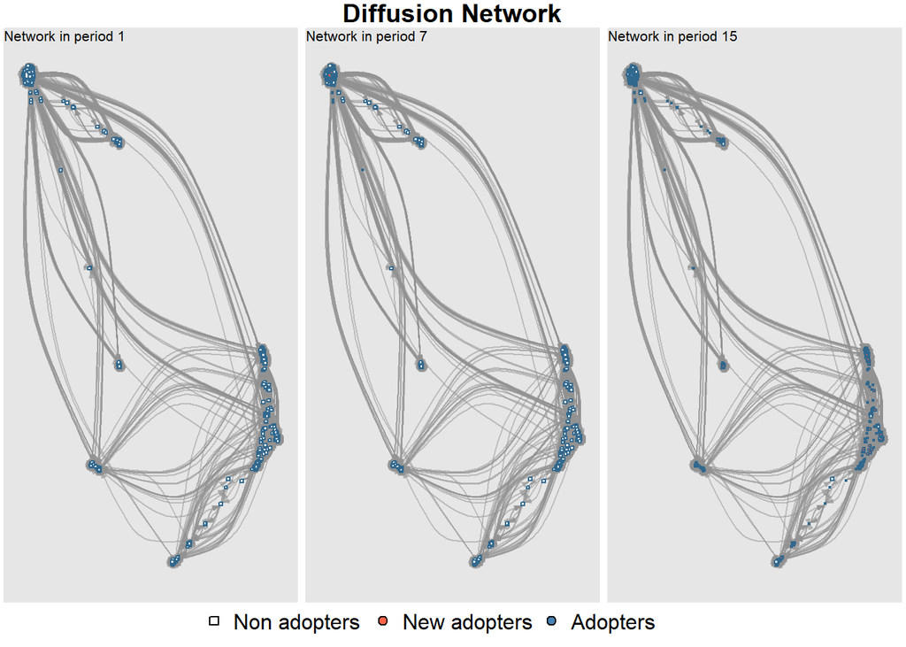

```r
plot_diffnet(diffnet_il_se, slices = c(1, 7, 15))
```

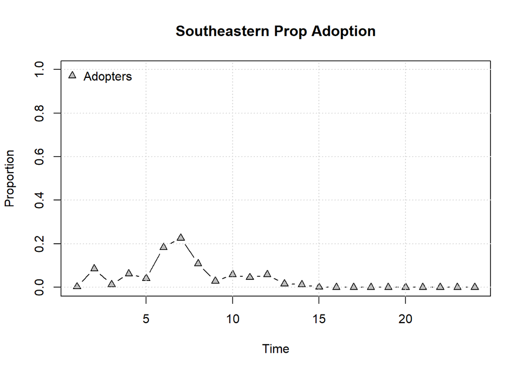

```r
plot_adopters(diffnet_il_se, what = "adopt", , main = "Southeastern Prop Adoption")
```

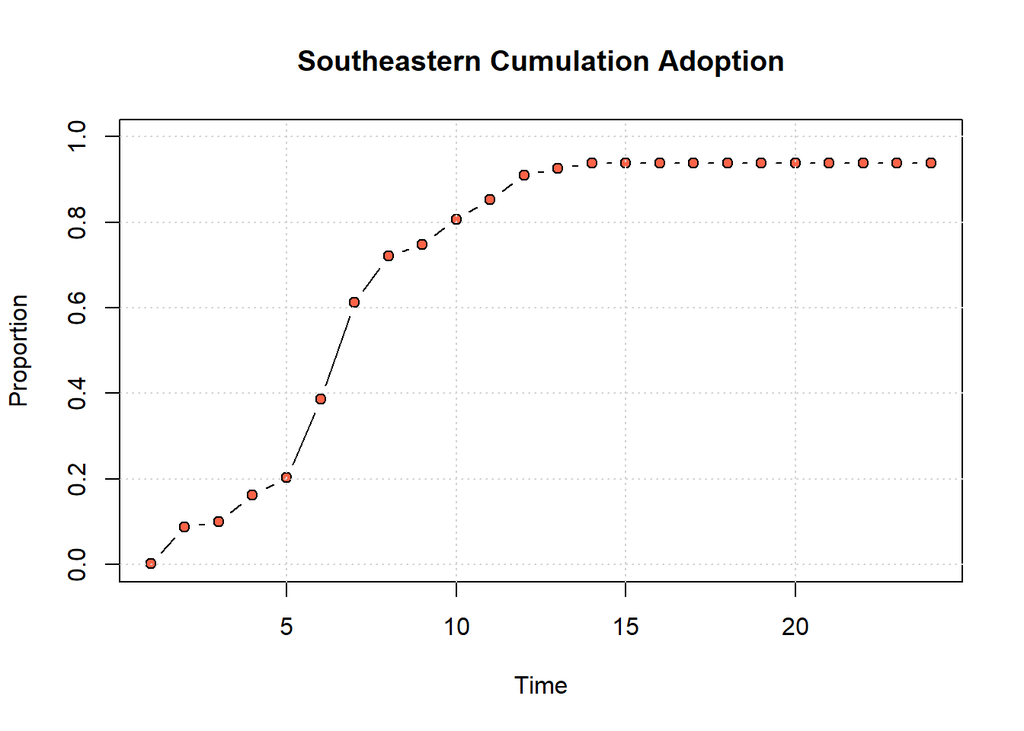

```r
plot_adopters(diffnet_il_se, what = "cumadopt", include.legend = FALSE, main = "Southeastern Cumulation Adoption")
```

Unsurprisingly, because we went with a really “strong storm” for our infection, and because Atlanta had the most nodes and a strong eigenvector centrality, the spread was very aggressive early (around T = 6 and T = 7) before peaking around 90% at t = 15.

North-Eastern Storm

```r
net_sna_adj <- as_adjacency_matrix(net)

#Philly
PHI <- match("1252", rownames(net_sna_adj))
#JFK
JFK <- match("766", rownames(net_sna_adj))
#LGA
LGA <- match("902", rownames(net_sna_adj))
#Newark
NEW <- match("500", rownames(net_sna_adj))

set.seed(1)
diffnet_il_ne <- rdiffnet(
  # n = 63, #don't need because we're using a real graph
  t = 24,
  seed.graph = net_sna_adj,
  # rgraph.args = list(p = 0.3), #don't need because we're using a real graph
  seed.nodes = c(PHI, JFK, LGA, NEW), #Philly, JFK
  rewire = F,
  threshold.dist = function(i) 0.17, #severe storms
  exposure.args = list(normalized = T)
  )
diffnet_il_ne
```

```
## Dynamic network of class -diffnet-
##  Name               : A diffusion network
##  Behavior           : Random contagion
##  # of nodes         : 1572 (1, 2, 3, 4, 6, 7, 8, 9, ...)
##  # of time periods  : 24 (1 - 24)
##  Type               : directed
##  Final prevalence   : 0.94
##  Static attributes  : real_threshold (1)
##  Dynamic attributes : -
```

```r
summary(diffnet_il_ne)
```

```
## Diffusion network summary statistics
## Name     : A diffusion network
## Behavior : Random contagion
## -----------------------------------------------------------------------------
##  Period   Adopters   Cum Adopt. (%)   Hazard Rate   Density   Moran's I (sd)
## -------- ---------- ---------------- ------------- --------- ----------------
##        1          4         4 (0.00)             -      0.01 -0.00 (0.00)
##        2        133       137 (0.09)          0.08      0.01  0.02 (0.00) ***
##        3          8       145 (0.09)          0.01      0.01  0.02 (0.00) ***
##        4         74       219 (0.14)          0.05      0.01  0.03 (0.00) ***
##        5         26       245 (0.16)          0.02      0.01  0.03 (0.00) ***
##        6        229       474 (0.30)          0.17      0.01  0.04 (0.00) ***
##        7        283       757 (0.48)          0.26      0.01  0.07 (0.00) ***
##        8        323      1080 (0.69)          0.40      0.01  0.09 (0.00) ***
##        9         67      1147 (0.73)          0.14      0.01  0.09 (0.00) ***
##       10         63      1210 (0.77)          0.15      0.01  0.08 (0.00) ***
##       11         59      1269 (0.81)          0.16      0.01  0.07 (0.00) ***
##       12         71      1340 (0.85)          0.23      0.01  0.05 (0.00) ***
##       13         91      1431 (0.91)          0.39      0.01  0.03 (0.00) ***
##       14         25      1456 (0.93)          0.18      0.01  0.02 (0.00) ***
##       15         19      1475 (0.94)          0.16      0.01  0.01 (0.00) ***
##       16          1      1476 (0.94)          0.01      0.01  0.01 (0.00) ***
##       17          0      1476 (0.94)          0.00      0.01  0.01 (0.00) ***
##       18          0      1476 (0.94)          0.00      0.01  0.01 (0.00) ***
##       19          0      1476 (0.94)          0.00      0.01  0.01 (0.00) ***
##       20          0      1476 (0.94)          0.00      0.01  0.01 (0.00) ***
##       21          0      1476 (0.94)          0.00      0.01  0.01 (0.00) ***
##       22          0      1476 (0.94)          0.00      0.01  0.01 (0.00) ***
##       23          0      1476 (0.94)          0.00      0.01  0.01 (0.00) ***
##       24          0      1476 (0.94)          0.00      0.01  0.01 (0.00) ***
## -----------------------------------------------------------------------------
##  Left censoring  : 0.00 (4)
##  Right centoring : 0.06 (96)
##  # of nodes      : 1572
##
##  Moran's I was computed on contemporaneous autocorrelation using 1/geodesic
##  values. Significane levels  *** <= .01, ** <= .05, * <= .1.
```

```r
table(diffnet_il_ne$toa) # time of adoption
```

```
##
##   1   2   3   4   5   6   7   8   9  10  11  12  13  14  15  16
##   4 133   8  74  26 229 283 323  67  63  59  71  91  25  19   1
```

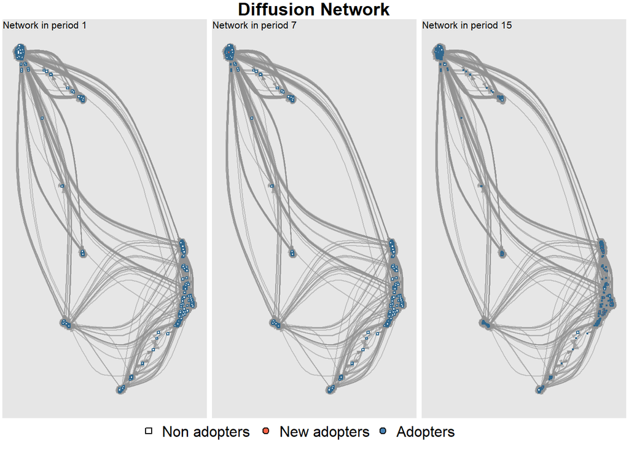

```r
plot_diffnet(diffnet_il_ne, slices = c(1, 7, 15))
```

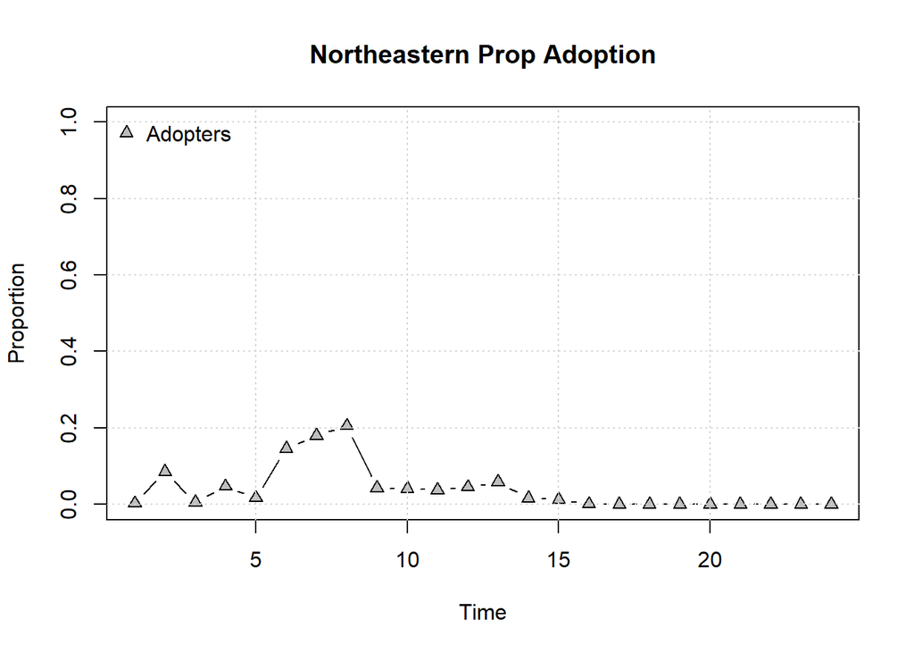

```r
plot_adopters(diffnet_il_ne, what = "adopt", main = "Northeastern Prop Adoption")
```

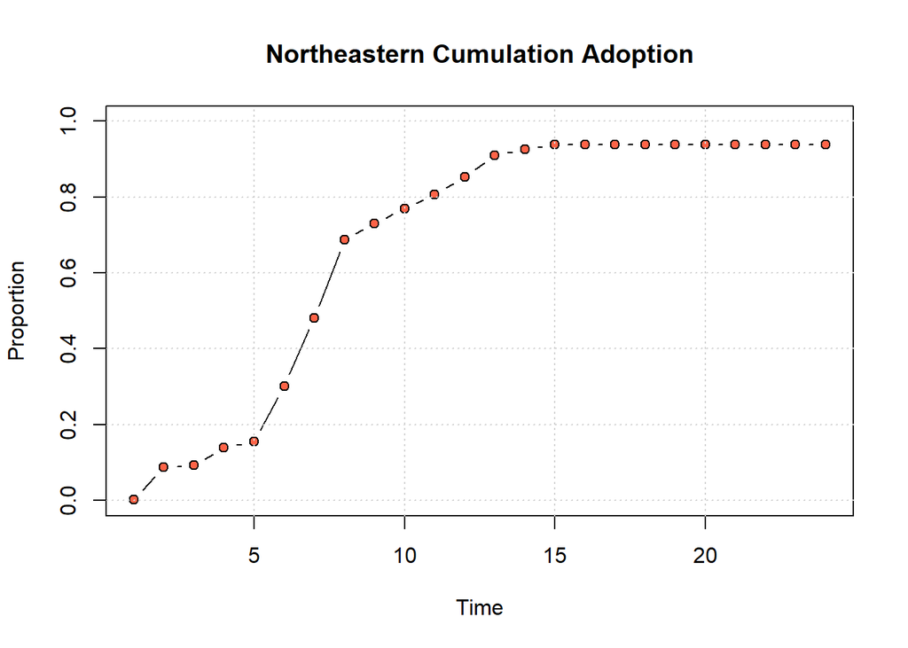

```r
plot_adopters(diffnet_il_ne, what = "cumadopt", include.legend = FALSE, main = "Northeastern Cumulation Adoption")
```

For the Northeastern plot, it generally followed a very similar trend as the Southeastern simulation. It is worth noting that the infection spread a little bit slower, but also had aggressive growth at t = 6, 7 and 8, before peaking at 90% around t = 15.

Western Storm

```r
net_sna_adj <- as_adjacency_matrix(net)

#LAX
LAX <- match("877", rownames(net_sna_adj))
#SFO
SFO <- match("1437", rownames(net_sna_adj))
#SAN
SAN <- match("1403", rownames(net_sna_adj))
#OAK
PHX <- match("1255", rownames(net_sna_adj))


set.seed(1)
diffnet_il_wes <- rdiffnet(
  # n = 63, #don't need because we're using a real graph
  t = 24,
  seed.graph = net_sna_adj,
  # rgraph.args = list(p = 0.3), #don't need because we're using a real graph
  seed.nodes = c(LAX, SFO, SAN, PHX), #LAX, SFO, SAN, OAK
  rewire = F,
  threshold.dist = function(i) 0.17, #severe storms
  exposure.args = list(normalized = T)
  )
diffnet_il_wes
```

```
## Dynamic network of class -diffnet-
##  Name               : A diffusion network
##  Behavior           : Random contagion
##  # of nodes         : 1572 (1, 2, 3, 4, 6, 7, 8, 9, ...)
##  # of time periods  : 24 (1 - 24)
##  Type               : directed
##  Final prevalence   : 0.94
##  Static attributes  : real_threshold (1)
##  Dynamic attributes : -
```

```r
summary(diffnet_il_wes)
```

```
## Diffusion network summary statistics
## Name     : A diffusion network
## Behavior : Random contagion
## -----------------------------------------------------------------------------
##  Period   Adopters   Cum Adopt. (%)   Hazard Rate   Density   Moran's I (sd)
## -------- ---------- ---------------- ------------- --------- ----------------
##        1          4         4 (0.00)             -      0.01  0.00 (0.00)
##        2         76        80 (0.05)          0.05      0.01  0.01 (0.00) ***
##        3         21       101 (0.06)          0.01      0.01  0.01 (0.00) ***
##        4         19       120 (0.08)          0.01      0.01  0.01 (0.00) ***
##        5         41       161 (0.10)          0.03      0.01  0.02 (0.00) ***
##        6          9       170 (0.11)          0.01      0.01  0.02 (0.00) ***
##        7         16       186 (0.12)          0.01      0.01  0.02 (0.00) ***
##        8          4       190 (0.12)          0.00      0.01  0.02 (0.00) ***
##        9          8       198 (0.13)          0.01      0.01  0.02 (0.00) ***
##       10         25       223 (0.14)          0.02      0.01  0.02 (0.00) ***
##       11         25       248 (0.16)          0.02      0.01  0.02 (0.00) ***
##       12         18       266 (0.17)          0.01      0.01  0.02 (0.00) ***
##       13         60       326 (0.21)          0.05      0.01  0.03 (0.00) ***
##       14         98       424 (0.27)          0.08      0.01  0.03 (0.00) ***
##       15        359       783 (0.50)          0.31      0.01  0.05 (0.00) ***
##       16        374      1157 (0.74)          0.47      0.01  0.08 (0.00) ***
##       17         55      1212 (0.77)          0.13      0.01  0.08 (0.00) ***
##       18         66      1278 (0.81)          0.18      0.01  0.06 (0.00) ***
##       19         62      1340 (0.85)          0.21      0.01  0.05 (0.00) ***
##       20         91      1431 (0.91)          0.39      0.01  0.03 (0.00) ***
##       21         25      1456 (0.93)          0.18      0.01  0.02 (0.00) ***
##       22         19      1475 (0.94)          0.16      0.01  0.01 (0.00) ***
##       23          1      1476 (0.94)          0.01      0.01  0.01 (0.00) ***
##       24          0      1476 (0.94)          0.00      0.01  0.01 (0.00) ***
## -----------------------------------------------------------------------------
##  Left censoring  : 0.00 (4)
##  Right centoring : 0.06 (96)
##  # of nodes      : 1572
##
##  Moran's I was computed on contemporaneous autocorrelation using 1/geodesic
##  values. Significane levels  *** <= .01, ** <= .05, * <= .1.
```

```r
table(diffnet_il_wes$toa) # time of adoption
```

```
##
##   1   2   3   4   5   6   7   8   9  10  11  12  13  14  15  16  17  18  19  20
##   4  76  21  19  41   9  16   4   8  25  25  18  60  98 359 374  55  66  62  91
##  21  22  23
##  25  19   1
```

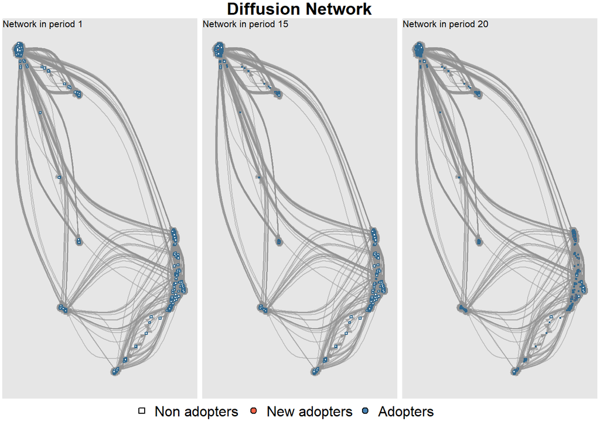

```r
plot_diffnet(diffnet_il_wes, slices = c(1, 15, 20))
```

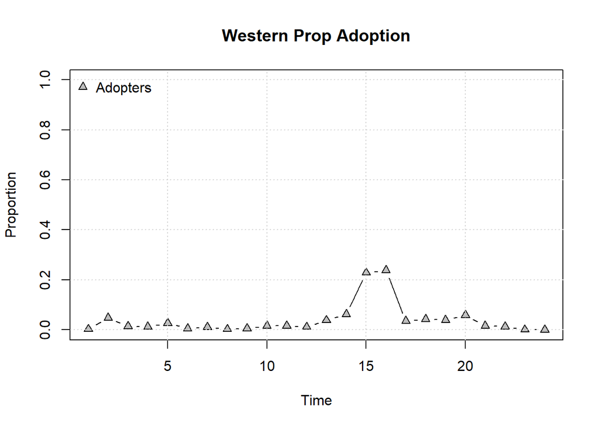

```r
plot_adopters(diffnet_il_wes, what = "adopt", main = "Western Prop Adoption")
```

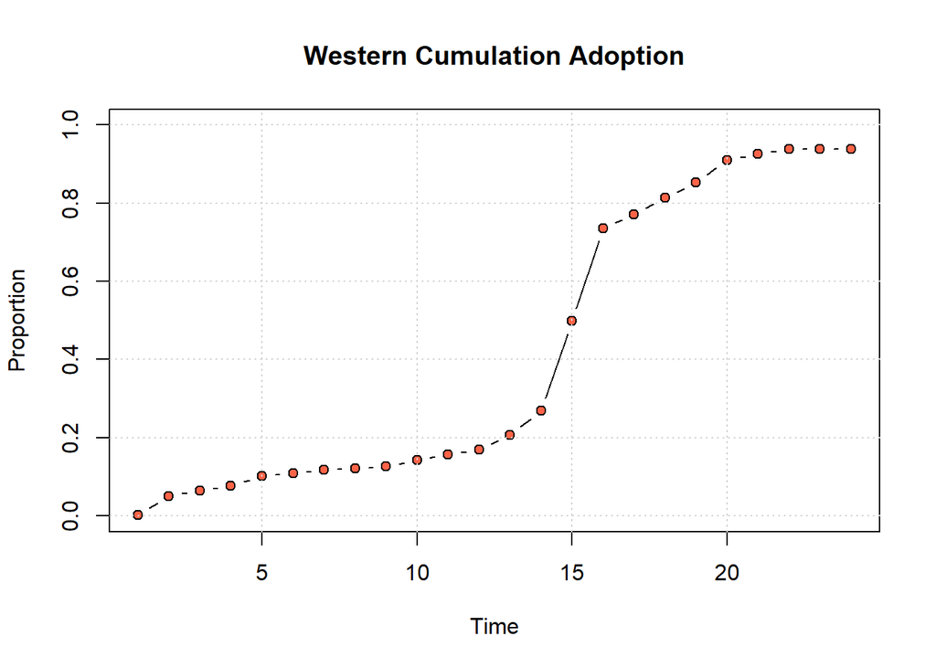

```r
plot_adopters(diffnet_il_wes, what = "cumadopt", include.legend = FALSE, main = "Western Cumulation Adoption")
```

For the Western plot started off much slower than both the southeastern and northeastern simulation and didn’t really seem to spread until t = 15 and t = 16 before peaking at t = 22 at 90%. So while the West did hit the same peak, the spread was much more limited than the first two.

Midwestern Storm

```r
net_sna_adj <- as_adjacency_matrix(net)

#How we found the seeds for each node
MDW <- match("989", rownames(net_sna_adj))
ORD <- match("1200", rownames(net_sna_adj))
DET <- match("390", rownames(net_sna_adj))
MSP <- match("1068", rownames(net_sna_adj))
STL <- match("1517", rownames(net_sna_adj))

set.seed(1)
diffnet_il_mdw <- rdiffnet(
  # n = 63, #don't need because we're using a real graph
  t = 24,
  seed.graph = net_sna_adj,
  # rgraph.args = list(p = 0.3), #don't need because we're using a real graph
  seed.nodes = c(MDW, ORD, DET, MSP, STL), # Atlanta, Orlando, TB, Miami
  rewire = F,
  threshold.dist = function(i) 0.15, #severe storms
  exposure.args = list(normalized = T)
  )
diffnet_il_mdw
```

```
## Dynamic network of class -diffnet-
##  Name               : A diffusion network
##  Behavior           : Random contagion
##  # of nodes         : 1572 (1, 2, 3, 4, 6, 7, 8, 9, ...)
##  # of time periods  : 24 (1 - 24)
##  Type               : directed
##  Final prevalence   : 0.82
##  Static attributes  : real_threshold (1)
##  Dynamic attributes : -
```

```r
summary(diffnet_il_mdw)
```

```
## Diffusion network summary statistics
## Name     : A diffusion network
## Behavior : Random contagion
## -----------------------------------------------------------------------------
##  Period   Adopters   Cum Adopt. (%)   Hazard Rate   Density   Moran's I (sd)
## -------- ---------- ---------------- ------------- --------- ----------------
##        1          5         5 (0.00)             -      0.01 -0.00 (0.00)
##        2         68        73 (0.05)          0.04      0.01  0.01 (0.00) ***
##        3         12        85 (0.05)          0.01      0.01  0.01 (0.00) ***
##        4          8        93 (0.06)          0.01      0.01  0.01 (0.00) ***
##        5          3        96 (0.06)          0.00      0.01  0.01 (0.00) ***
##        6          3        99 (0.06)          0.00      0.01  0.01 (0.00) ***
##        7         11       110 (0.07)          0.01      0.01  0.01 (0.00) ***
##        8          7       117 (0.07)          0.00      0.01  0.01 (0.00) ***
##        9          7       124 (0.08)          0.00      0.01  0.01 (0.00) ***
##       10          6       130 (0.08)          0.00      0.01  0.01 (0.00) ***
##       11          5       135 (0.09)          0.00      0.01  0.01 (0.00) ***
##       12          3       138 (0.09)          0.00      0.01  0.01 (0.00) ***
##       13         10       148 (0.09)          0.01      0.01  0.01 (0.00) ***
##       14          7       155 (0.10)          0.00      0.01  0.01 (0.00) ***
##       15          3       158 (0.10)          0.00      0.01  0.01 (0.00) ***
##       16          6       164 (0.10)          0.00      0.01  0.01 (0.00) ***
##       17         20       184 (0.12)          0.01      0.01  0.01 (0.00) ***
##       18         44       228 (0.15)          0.03      0.01  0.02 (0.00) ***
##       19        181       409 (0.26)          0.13      0.01  0.04 (0.00) ***
##       20        465       874 (0.56)          0.40      0.01  0.08 (0.00) ***
##       21        222      1096 (0.70)          0.32      0.01  0.10 (0.00) ***
##       22         66      1162 (0.74)          0.14      0.01  0.09 (0.00) ***
##       23         55      1217 (0.77)          0.13      0.01  0.08 (0.00) ***
##       24         74      1291 (0.82)          0.21      0.01  0.06 (0.00) ***
## -----------------------------------------------------------------------------
##  Left censoring  : 0.00 (5)
##  Right centoring : 0.18 (281)
##  # of nodes      : 1572
##
##  Moran's I was computed on contemporaneous autocorrelation using 1/geodesic
##  values. Significane levels  *** <= .01, ** <= .05, * <= .1.
```

```r
table(diffnet_il_mdw$toa) # time of adoption
```

```
##
##   1   2   3   4   5   6   7   8   9  10  11  12  13  14  15  16  17  18  19  20
##   5  68  12   8   3   3  11   7   7   6   5   3  10   7   3   6  20  44 181 465
##  21  22  23  24
## 222  66  55  74
```

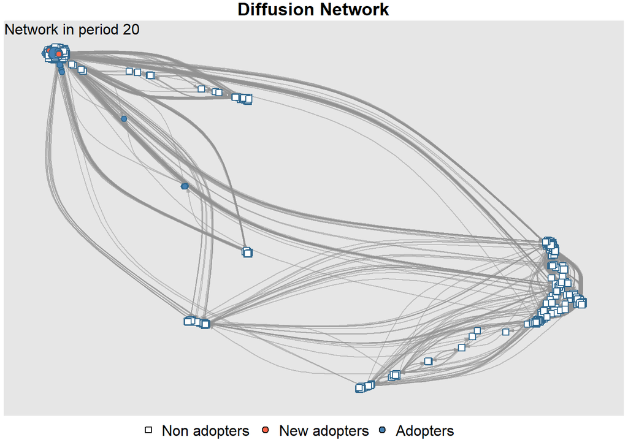

```r
plot_diffnet(diffnet_il_mdw, slices = c(20))
```

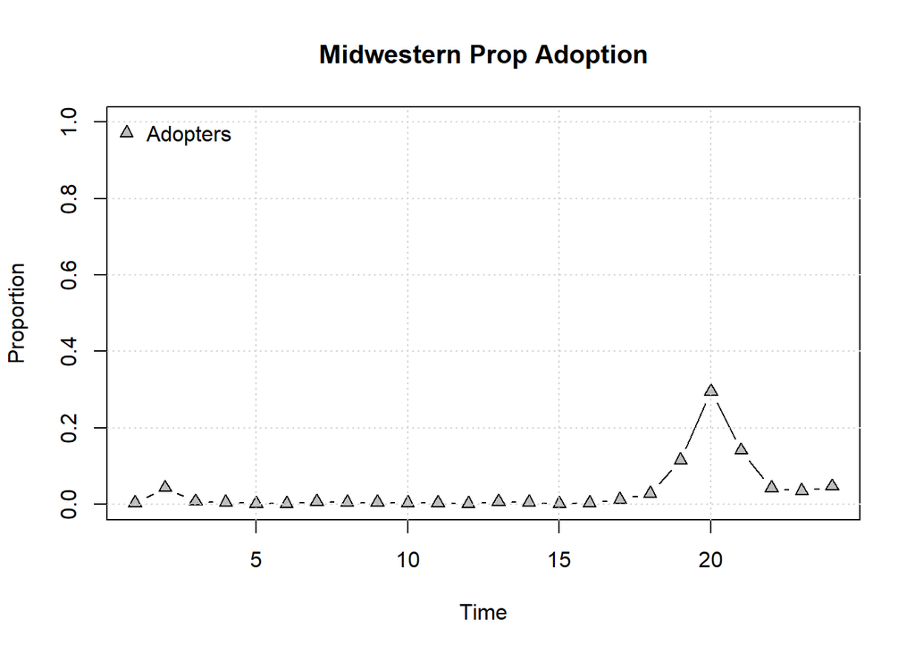

```r
plot_adopters(diffnet_il_mdw, what = "adopt", main = "Midwestern Prop Adoption")
```

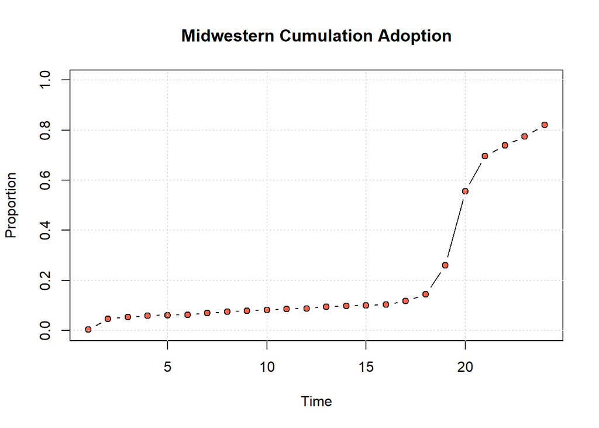

```r
plot_adopters(diffnet_il_mdw, what = "cumadopt", include.legend = FALSE, main = "Midwestern Cumulation Adoption")
```

We were surprised by the Midwestern simulation because Detroit and O’Hare had a very high eigenvector centrality but were slow to spread, waiting until t = 19 and t = 20 to really reach the majority of the network. There is evidence to suspect that the network would continue to be infected past the 24 hour mark, but for the sake of our simulations we limited it to 24.

In conclusion we found that the Northeastern and Southeastern airports generally tended to lead to more dramatic “delays” that spread through the US Airport Network much quicker than their Western and Midwestern airports, suggesting that Atlanta and the New York Airports are incredibly important to the US Airport Network.